# Risk Factor Analysis

## Outcome Variable

**Outcome Variable:** ever_co

## Predictor Variables

**Intervention Variable:** earlybf

**Adjustment Set:**

- arm
- sex
- W_mage
- meducyrs
- feducyrs
- hhwealth_quart
- hfoodsec
- W_mhtcm
- vagbrth
- W_birthwt
- W_birthlen
- W_nrooms
- W_nchldlt5
- brthmon
- W_parity
- impfloor
- impsan
- safeh20
- delta_W_mage
- delta_meducyrs
- delta_feducyrs
- delta_hhwealth_quart
- delta_hfoodsec
- delta_W_mhtcm
- delta_vagbrth
- delta_W_birthwt
- delta_W_birthlen
- delta_W_nrooms
- delta_W_nchldlt5
- delta_brthmon
- delta_W_parity
- delta_impfloor
- delta_impsan
- delta_safeh20

## Stratifying Variables

The analysis was stratified on these variable(s):

- agecat
- studyid
- country

## Data Summary

| agecat | studyid | country | earlybf | ever_co | n_cell | n |
| --- | --- | --- | --- | --- | --- | --- |
| 0-24 months | ki0047075b-MAL-ED | BANGLADESH | 1 | 0 | 140 | 262 |
| 0-24 months | ki0047075b-MAL-ED | BANGLADESH | 1 | 1 | 21 | 262 |
| 0-24 months | ki0047075b-MAL-ED | BANGLADESH | 0 | 0 | 84 | 262 |
| 0-24 months | ki0047075b-MAL-ED | BANGLADESH | 0 | 1 | 17 | 262 |
| 0-24 months | ki0047075b-MAL-ED | BRAZIL | 1 | 0 | 108 | 233 |
| 0-24 months | ki0047075b-MAL-ED | BRAZIL | 1 | 1 | 0 | 233 |
| 0-24 months | ki0047075b-MAL-ED | BRAZIL | 0 | 0 | 123 | 233 |
| 0-24 months | ki0047075b-MAL-ED | BRAZIL | 0 | 1 | 2 | 233 |
| 0-24 months | ki0047075b-MAL-ED | INDIA | 1 | 0 | 115 | 250 |
| 0-24 months | ki0047075b-MAL-ED | INDIA | 1 | 1 | 33 | 250 |
| 0-24 months | ki0047075b-MAL-ED | INDIA | 0 | 0 | 81 | 250 |
| 0-24 months | ki0047075b-MAL-ED | INDIA | 0 | 1 | 21 | 250 |
| 0-24 months | ki0047075b-MAL-ED | NEPAL | 1 | 0 | 89 | 240 |
| 0-24 months | ki0047075b-MAL-ED | NEPAL | 1 | 1 | 9 | 240 |
| 0-24 months | ki0047075b-MAL-ED | NEPAL | 0 | 0 | 130 | 240 |
| 0-24 months | ki0047075b-MAL-ED | NEPAL | 0 | 1 | 12 | 240 |
| 0-24 months | ki0047075b-MAL-ED | PERU | 1 | 0 | 214 | 302 |
| 0-24 months | ki0047075b-MAL-ED | PERU | 1 | 1 | 11 | 302 |
| 0-24 months | ki0047075b-MAL-ED | PERU | 0 | 0 | 76 | 302 |
| 0-24 months | ki0047075b-MAL-ED | PERU | 0 | 1 | 1 | 302 |
| 0-24 months | ki0047075b-MAL-ED | SOUTH AFRICA | 1 | 0 | 170 | 297 |
| 0-24 months | ki0047075b-MAL-ED | SOUTH AFRICA | 1 | 1 | 11 | 297 |
| 0-24 months | ki0047075b-MAL-ED | SOUTH AFRICA | 0 | 0 | 105 | 297 |
| 0-24 months | ki0047075b-MAL-ED | SOUTH AFRICA | 0 | 1 | 11 | 297 |
| 0-24 months | ki0047075b-MAL-ED | TANZANIA, UNITED REPUBLIC OF | 1 | 0 | 197 | 261 |
| 0-24 months | ki0047075b-MAL-ED | TANZANIA, UNITED REPUBLIC OF | 1 | 1 | 19 | 261 |
| 0-24 months | ki0047075b-MAL-ED | TANZANIA, UNITED REPUBLIC OF | 0 | 0 | 41 | 261 |
| 0-24 months | ki0047075b-MAL-ED | TANZANIA, UNITED REPUBLIC OF | 0 | 1 | 4 | 261 |
| 0-24 months | ki1000109-EE | PAKISTAN | 1 | 0 | 47 | 379 |
| 0-24 months | ki1000109-EE | PAKISTAN | 1 | 1 | 22 | 379 |

[output cut: 138 more lines]

The following strata were considered:

- agecat: 0-24 months, studyid: ki0047075b-MAL-ED, country: BANGLADESH
- agecat: 0-24 months, studyid: ki0047075b-MAL-ED, country: BRAZIL
- agecat: 0-24 months, studyid: ki0047075b-MAL-ED, country: INDIA
- agecat: 0-24 months, studyid: ki0047075b-MAL-ED, country: NEPAL
- agecat: 0-24 months, studyid: ki0047075b-MAL-ED, country: PERU
- agecat: 0-24 months, studyid: ki0047075b-MAL-ED, country: SOUTH AFRICA
- agecat: 0-24 months, studyid: ki0047075b-MAL-ED, country: TANZANIA, UNITED REPUBLIC OF
- agecat: 0-24 months, studyid: ki1000109-EE, country: PAKISTAN
- agecat: 0-24 months, studyid: ki1000304b-SAS-CompFeed, country: INDIA
- agecat: 0-24 months, studyid: ki1017093c-NIH-Crypto, country: BANGLADESH
- agecat: 0-24 months, studyid: ki1113344-GMS-Nepal, country: NEPAL
- agecat: 0-24 months, studyid: ki1126311-ZVITAMBO, country: ZIMBABWE
- agecat: 0-24 months, studyid: kiGH5241-JiVitA-3, country: BANGLADESH
- agecat: 0-24 months, studyid: kiGH5241-JiVitA-4, country: BANGLADESH
- agecat: 0-6 months, studyid: ki0047075b-MAL-ED, country: BANGLADESH
- agecat: 0-6 months, studyid: ki0047075b-MAL-ED, country: BRAZIL
- agecat: 0-6 months, studyid: ki0047075b-MAL-ED, country: INDIA
- agecat: 0-6 months, studyid: ki0047075b-MAL-ED, country: NEPAL
- agecat: 0-6 months, studyid: ki0047075b-MAL-ED, country: PERU
- agecat: 0-6 months, studyid: ki0047075b-MAL-ED, country: SOUTH AFRICA
- agecat: 0-6 months, studyid: ki0047075b-MAL-ED, country: TANZANIA, UNITED REPUBLIC OF
- agecat: 0-6 months, studyid: ki1000109-EE, country: PAKISTAN
- agecat: 0-6 months, studyid: ki1000304b-SAS-CompFeed, country: INDIA
- agecat: 0-6 months, studyid: ki1017093c-NIH-Crypto, country: BANGLADESH
- agecat: 0-6 months, studyid: ki1113344-GMS-Nepal, country: NEPAL
- agecat: 0-6 months, studyid: ki1126311-ZVITAMBO, country: ZIMBABWE
- agecat: 0-6 months, studyid: kiGH5241-JiVitA-3, country: BANGLADESH
- agecat: 0-6 months, studyid: kiGH5241-JiVitA-4, country: BANGLADESH
- agecat: 6-24 months, studyid: ki0047075b-MAL-ED, country: BANGLADESH
- agecat: 6-24 months, studyid: ki0047075b-MAL-ED, country: BRAZIL
- agecat: 6-24 months, studyid: ki0047075b-MAL-ED, country: INDIA
- agecat: 6-24 months, studyid: ki0047075b-MAL-ED, country: NEPAL
- agecat: 6-24 months, studyid: ki0047075b-MAL-ED, country: PERU
- agecat: 6-24 months, studyid: ki0047075b-MAL-ED, country: SOUTH AFRICA
- agecat: 6-24 months, studyid: ki0047075b-MAL-ED, country: TANZANIA, UNITED REPUBLIC OF
- agecat: 6-24 months, studyid: ki1000109-EE, country: PAKISTAN
- agecat: 6-24 months, studyid: ki1000304b-SAS-CompFeed, country: INDIA
- agecat: 6-24 months, studyid: ki1017093c-NIH-Crypto, country: BANGLADESH
- agecat: 6-24 months, studyid: ki1113344-GMS-Nepal, country: NEPAL
- agecat: 6-24 months, studyid: ki1126311-ZVITAMBO, country: ZIMBABWE
- agecat: 6-24 months, studyid: kiGH5241-JiVitA-3, country: BANGLADESH
- agecat: 6-24 months, studyid: kiGH5241-JiVitA-4, country: BANGLADESH

### Dropped Strata

Some strata were dropped due to rare outcomes:

- agecat: 0-24 months, studyid: ki0047075b-MAL-ED, country: BRAZIL
- agecat: 0-24 months, studyid: ki0047075b-MAL-ED, country: PERU
- agecat: 0-24 months, studyid: ki0047075b-MAL-ED, country: TANZANIA, UNITED REPUBLIC OF
- agecat: 0-6 months, studyid: ki0047075b-MAL-ED, country: BANGLADESH
- agecat: 0-6 months, studyid: ki0047075b-MAL-ED, country: BRAZIL
- agecat: 0-6 months, studyid: ki0047075b-MAL-ED, country: NEPAL
- agecat: 0-6 months, studyid: ki0047075b-MAL-ED, country: PERU
- agecat: 0-6 months, studyid: ki0047075b-MAL-ED, country: SOUTH AFRICA
- agecat: 0-6 months, studyid: ki0047075b-MAL-ED, country: TANZANIA, UNITED REPUBLIC OF
- agecat: 0-6 months, studyid: ki1017093c-NIH-Crypto, country: BANGLADESH
- agecat: 0-6 months, studyid: ki1113344-GMS-Nepal, country: NEPAL
- agecat: 6-24 months, studyid: ki0047075b-MAL-ED, country: BRAZIL
- agecat: 6-24 months, studyid: ki0047075b-MAL-ED, country: PERU
- agecat: 6-24 months, studyid: ki0047075b-MAL-ED, country: TANZANIA, UNITED REPUBLIC OF
- agecat: 6-24 months, studyid: ki1017093c-NIH-Crypto, country: BANGLADESH
- agecat: 6-24 months, studyid: kiGH5241-JiVitA-3, country: BANGLADESH

## Methods Detail

We’re interested in the causal parameters $E[Y_a]$ for all values of $a \in \mathcal{A}$. These parameters represent the mean outcome if, possibly contrary to fact, we intervened to set all units to have $A=a$. Under the randomization and positivity assumptions, these are identified by the statistical parameters $\psi_a=E_W[E_{Y|A,W}(Y|A=a,W)]$. In addition, we’re interested in the mean of $Y$, $E[Y]$ under no intervention (the observed mean). We will estimate these parameters by using SuperLearner to fit the relevant likelihood factors – $E_{Y|A,W}(Y|A=a,W)$ and $p(A=a|W)$, and then updating our likelihood fit using a joint TMLE.

For unadjusted analyses ($W=\{\}$), initial likelihoods were estimated using Lrnr_glm to estimate the simple $E(Y|A)$ and Lrnr_mean to estimate $p(A)$. For adjusted analyses, a small library containing Lrnr_glmnet, Lrnr_xgboost, and Lrnr_mean was used.

Having estimated these parameters, we will then use the delta method to estimate relative risks and attributable risks relative to a prespecified baseline level of $A$.

# Results Detail

## Results Plots

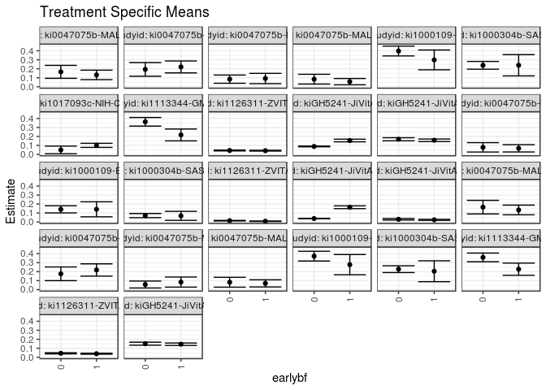

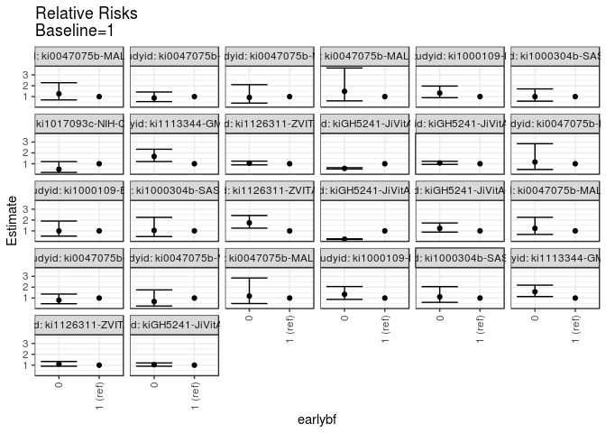

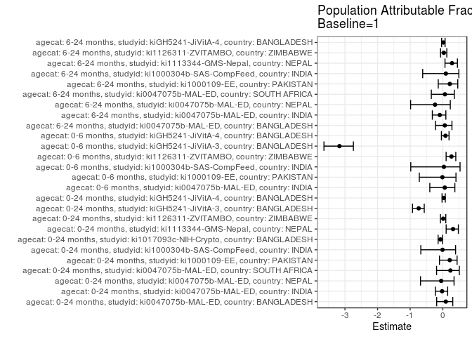

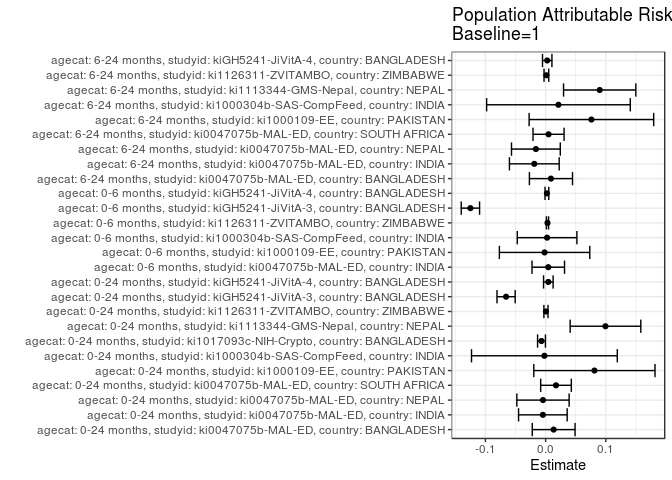

## Results Table

### Parameter: TSM

| agecat | studyid | country | intervention_level | baseline_level | estimate | ci_lower | ci_upper |
| --- | --- | --- | --- | --- | --- | --- | --- |
| 0-24 months | ki0047075b-MAL-ED | BANGLADESH | 1 | NA | 0.1316598 | 0.0788695 | 0.1844502 |
| 0-24 months | ki0047075b-MAL-ED | BANGLADESH | 0 | NA | 0.1658280 | 0.0938982 | 0.2377577 |
| 0-24 months | ki0047075b-MAL-ED | INDIA | 1 | NA | 0.2205503 | 0.1540208 | 0.2870799 |
| 0-24 months | ki0047075b-MAL-ED | INDIA | 0 | NA | 0.1931953 | 0.1172463 | 0.2691444 |
| 0-24 months | ki0047075b-MAL-ED | NEPAL | 1 | NA | 0.0918367 | 0.0345397 | 0.1491337 |
| 0-24 months | ki0047075b-MAL-ED | NEPAL | 0 | NA | 0.0845070 | 0.0386628 | 0.1303513 |
| 0-24 months | ki0047075b-MAL-ED | SOUTH AFRICA | 1 | NA | 0.0568087 | 0.0217151 | 0.0919022 |
| 0-24 months | ki0047075b-MAL-ED | SOUTH AFRICA | 0 | NA | 0.0842460 | 0.0299695 | 0.1385226 |
| 0-24 months | ki1000109-EE | PAKISTAN | 1 | NA | 0.2988885 | 0.1889134 | 0.4088636 |
| 0-24 months | ki1000109-EE | PAKISTAN | 0 | NA | 0.3973995 | 0.3428065 | 0.4519925 |
| 0-24 months | ki1000304b-SAS-CompFeed | INDIA | 1 | NA | 0.2390724 | 0.1210346 | 0.3571102 |
| 0-24 months | ki1000304b-SAS-CompFeed | INDIA | 0 | NA | 0.2383331 | 0.1953451 | 0.2813211 |
| 0-24 months | ki1017093c-NIH-Crypto | BANGLADESH | 1 | NA | 0.1004566 | 0.0774553 | 0.1234579 |
| 0-24 months | ki1017093c-NIH-Crypto | BANGLADESH | 0 | NA | 0.0495050 | 0.0071725 | 0.0918374 |
| 0-24 months | ki1113344-GMS-Nepal | NEPAL | 1 | NA | 0.2162351 | 0.1502720 | 0.2821983 |
| 0-24 months | ki1113344-GMS-Nepal | NEPAL | 0 | NA | 0.3625648 | 0.3146182 | 0.4105114 |
| 0-24 months | ki1126311-ZVITAMBO | ZIMBABWE | 1 | NA | 0.0411933 | 0.0364067 | 0.0459798 |
| 0-24 months | ki1126311-ZVITAMBO | ZIMBABWE | 0 | NA | 0.0434509 | 0.0382855 | 0.0486163 |
| 0-24 months | kiGH5241-JiVitA-3 | BANGLADESH | 1 | NA | 0.1543566 | 0.1395588 | 0.1691544 |
| 0-24 months | kiGH5241-JiVitA-3 | BANGLADESH | 0 | NA | 0.0882712 | 0.0842802 | 0.0922622 |
| 0-24 months | kiGH5241-JiVitA-4 | BANGLADESH | 1 | NA | 0.1567891 | 0.1427462 | 0.1708321 |
| 0-24 months | kiGH5241-JiVitA-4 | BANGLADESH | 0 | NA | 0.1682556 | 0.1509379 | 0.1855733 |
| 0-6 months | ki0047075b-MAL-ED | INDIA | 1 | NA | 0.0675676 | 0.0270479 | 0.1080872 |
| 0-6 months | ki0047075b-MAL-ED | INDIA | 0 | NA | 0.0784314 | 0.0261524 | 0.1307104 |
| 0-6 months | ki1000109-EE | PAKISTAN | 1 | NA | 0.1415450 | 0.0581030 | 0.2249870 |
| 0-6 months | ki1000109-EE | PAKISTAN | 0 | NA | 0.1408646 | 0.1015215 | 0.1802076 |
| 0-6 months | ki1000304b-SAS-CompFeed | INDIA | 1 | NA | 0.0686275 | 0.0186437 | 0.1186112 |
| 0-6 months | ki1000304b-SAS-CompFeed | INDIA | 0 | NA | 0.0712711 | 0.0481167 | 0.0944255 |
| 0-6 months | ki1126311-ZVITAMBO | ZIMBABWE | 1 | NA | 0.0086445 | 0.0064145 | 0.0108745 |
| 0-6 months | ki1126311-ZVITAMBO | ZIMBABWE | 0 | NA | 0.0150577 | 0.0119401 | 0.0181753 |
| 0-6 months | kiGH5241-JiVitA-3 | BANGLADESH | 1 | NA | 0.1643110 | 0.1490713 | 0.1795508 |
| 0-6 months | kiGH5241-JiVitA-3 | BANGLADESH | 0 | NA | 0.0386519 | 0.0360981 | 0.0412058 |
| 0-6 months | kiGH5241-JiVitA-4 | BANGLADESH | 1 | NA | 0.0243359 | 0.0183858 | 0.0302861 |
| 0-6 months | kiGH5241-JiVitA-4 | BANGLADESH | 0 | NA | 0.0301759 | 0.0216426 | 0.0387092 |
| 6-24 months | ki0047075b-MAL-ED | BANGLADESH | 1 | NA | 0.1339517 | 0.0801392 | 0.1877642 |
| 6-24 months | ki0047075b-MAL-ED | BANGLADESH | 0 | NA | 0.1651740 | 0.0894795 | 0.2408686 |
| 6-24 months | ki0047075b-MAL-ED | INDIA | 1 | NA | 0.2187477 | 0.1505836 | 0.2869119 |
| 6-24 months | ki0047075b-MAL-ED | INDIA | 0 | NA | 0.1762335 | 0.1001170 | 0.2523500 |
| 6-24 months | ki0047075b-MAL-ED | NEPAL | 1 | NA | 0.0842105 | 0.0282485 | 0.1401725 |
| 6-24 months | ki0047075b-MAL-ED | NEPAL | 0 | NA | 0.0571429 | 0.0186115 | 0.0956742 |
| 6-24 months | ki0047075b-MAL-ED | SOUTH AFRICA | 1 | NA | 0.0696203 | 0.0298580 | 0.1093825 |
| 6-24 months | ki0047075b-MAL-ED | SOUTH AFRICA | 0 | NA | 0.0824742 | 0.0276233 | 0.1373251 |
| 6-24 months | ki1000109-EE | PAKISTAN | 1 | NA | 0.2778103 | 0.1654765 | 0.3901441 |
| 6-24 months | ki1000109-EE | PAKISTAN | 0 | NA | 0.3724917 | 0.3181933 | 0.4267901 |
| 6-24 months | ki1000304b-SAS-CompFeed | INDIA | 1 | NA | 0.2047060 | 0.0882877 | 0.3211243 |
| 6-24 months | ki1000304b-SAS-CompFeed | INDIA | 0 | NA | 0.2278824 | 0.1902459 | 0.2655189 |
| 6-24 months | ki1113344-GMS-Nepal | NEPAL | 1 | NA | 0.2273175 | 0.1594182 | 0.2952169 |
| 6-24 months | ki1113344-GMS-Nepal | NEPAL | 0 | NA | 0.3586425 | 0.3103582 | 0.4069268 |
| 6-24 months | ki1126311-ZVITAMBO | ZIMBABWE | 1 | NA | 0.0396005 | 0.0341795 | 0.0450215 |
| 6-24 months | ki1126311-ZVITAMBO | ZIMBABWE | 0 | NA | 0.0436386 | 0.0375053 | 0.0497719 |
| 6-24 months | kiGH5241-JiVitA-4 | BANGLADESH | 1 | NA | 0.1450311 | 0.1315671 | 0.1584951 |
| 6-24 months | kiGH5241-JiVitA-4 | BANGLADESH | 0 | NA | 0.1512234 | 0.1345645 | 0.1678823 |

### Parameter: E(Y)

| agecat | studyid | country | intervention_level | baseline_level | estimate | ci_lower | ci_upper |
| --- | --- | --- | --- | --- | --- | --- | --- |
| 0-24 months | ki0047075b-MAL-ED | BANGLADESH | NA | NA | 0.1450382 | 0.1023171 | 0.1877593 |
| 0-24 months | ki0047075b-MAL-ED | INDIA | NA | NA | 0.2160000 | 0.1648868 | 0.2671132 |
| 0-24 months | ki0047075b-MAL-ED | NEPAL | NA | NA | 0.0875000 | 0.0516764 | 0.1233236 |
| 0-24 months | ki0047075b-MAL-ED | SOUTH AFRICA | NA | NA | 0.0740741 | 0.0442393 | 0.1039089 |
| 0-24 months | ki1000109-EE | PAKISTAN | NA | NA | 0.3799472 | 0.3310169 | 0.4288776 |
| 0-24 months | ki1000304b-SAS-CompFeed | INDIA | NA | NA | 0.2370924 | 0.1969570 | 0.2772278 |
| 0-24 months | ki1017093c-NIH-Crypto | BANGLADESH | NA | NA | 0.0936675 | 0.0729118 | 0.1144233 |
| 0-24 months | ki1113344-GMS-Nepal | NEPAL | NA | NA | 0.3156934 | 0.2767430 | 0.3546439 |
| 0-24 months | ki1126311-ZVITAMBO | ZIMBABWE | NA | NA | 0.0417607 | 0.0382402 | 0.0452812 |
| 0-24 months | kiGH5241-JiVitA-3 | BANGLADESH | NA | NA | 0.0887349 | 0.0848433 | 0.0926265 |
| 0-24 months | kiGH5241-JiVitA-4 | BANGLADESH | NA | NA | 0.1613377 | 0.1500062 | 0.1726692 |
| 0-6 months | ki0047075b-MAL-ED | INDIA | NA | NA | 0.0720000 | 0.0398938 | 0.1041062 |
| 0-6 months | ki1000109-EE | PAKISTAN | NA | NA | 0.1398417 | 0.1048786 | 0.1748048 |
| 0-6 months | ki1000304b-SAS-CompFeed | INDIA | NA | NA | 0.0710868 | 0.0489978 | 0.0931759 |
| 0-6 months | ki1126311-ZVITAMBO | ZIMBABWE | NA | NA | 0.0117695 | 0.0098650 | 0.0136739 |
| 0-6 months | kiGH5241-JiVitA-3 | BANGLADESH | NA | NA | 0.0394196 | 0.0369302 | 0.0419089 |
| 0-6 months | kiGH5241-JiVitA-4 | BANGLADESH | NA | NA | 0.0265122 | 0.0211694 | 0.0318550 |
| 6-24 months | ki0047075b-MAL-ED | BANGLADESH | NA | NA | 0.1428571 | 0.0983068 | 0.1874075 |
| 6-24 months | ki0047075b-MAL-ED | INDIA | NA | NA | 0.2000000 | 0.1487493 | 0.2512507 |
| 6-24 months | ki0047075b-MAL-ED | NEPAL | NA | NA | 0.0680851 | 0.0358110 | 0.1003592 |
| 6-24 months | ki0047075b-MAL-ED | SOUTH AFRICA | NA | NA | 0.0745098 | 0.0422157 | 0.1068040 |
| 6-24 months | ki1000109-EE | PAKISTAN | NA | NA | 0.3538874 | 0.3052956 | 0.4024792 |
| 6-24 months | ki1000304b-SAS-CompFeed | INDIA | NA | NA | 0.2260619 | 0.1909133 | 0.2612105 |
| 6-24 months | ki1113344-GMS-Nepal | NEPAL | NA | NA | 0.3171642 | 0.2777301 | 0.3565982 |
| 6-24 months | ki1126311-ZVITAMBO | ZIMBABWE | NA | NA | 0.0409086 | 0.0369272 | 0.0448901 |
| 6-24 months | kiGH5241-JiVitA-4 | BANGLADESH | NA | NA | 0.1477252 | 0.1371297 | 0.1583206 |

### Parameter: RR

| agecat | studyid | country | intervention_level | baseline_level | estimate | ci_lower | ci_upper |
| --- | --- | --- | --- | --- | --- | --- | --- |
| 0-24 months | ki0047075b-MAL-ED | BANGLADESH | 1 | 1 | 1.0000000 | 1.0000000 | 1.0000000 |
| 0-24 months | ki0047075b-MAL-ED | BANGLADESH | 0 | 1 | 1.2595181 | 0.6963558 | 2.2781255 |
| 0-24 months | ki0047075b-MAL-ED | INDIA | 1 | 1 | 1.0000000 | 1.0000000 | 1.0000000 |
| 0-24 months | ki0047075b-MAL-ED | INDIA | 0 | 1 | 0.8759693 | 0.5382899 | 1.4254813 |
| 0-24 months | ki0047075b-MAL-ED | NEPAL | 1 | 1 | 1.0000000 | 1.0000000 | 1.0000000 |
| 0-24 months | ki0047075b-MAL-ED | NEPAL | 0 | 1 | 0.9201878 | 0.4025457 | 2.1034771 |
| 0-24 months | ki0047075b-MAL-ED | SOUTH AFRICA | 1 | 1 | 1.0000000 | 1.0000000 | 1.0000000 |
| 0-24 months | ki0047075b-MAL-ED | SOUTH AFRICA | 0 | 1 | 1.4829778 | 0.6048865 | 3.6357617 |
| 0-24 months | ki1000109-EE | PAKISTAN | 1 | 1 | 1.0000000 | 1.0000000 | 1.0000000 |
| 0-24 months | ki1000109-EE | PAKISTAN | 0 | 1 | 1.3295911 | 0.8983032 | 1.9679463 |
| 0-24 months | ki1000304b-SAS-CompFeed | INDIA | 1 | 1 | 1.0000000 | 1.0000000 | 1.0000000 |
| 0-24 months | ki1000304b-SAS-CompFeed | INDIA | 0 | 1 | 0.9969078 | 0.5815983 | 1.7087827 |
| 0-24 months | ki1017093c-NIH-Crypto | BANGLADESH | 1 | 1 | 1.0000000 | 1.0000000 | 1.0000000 |
| 0-24 months | ki1017093c-NIH-Crypto | BANGLADESH | 0 | 1 | 0.4927993 | 0.2033366 | 1.1943305 |
| 0-24 months | ki1113344-GMS-Nepal | NEPAL | 1 | 1 | 1.0000000 | 1.0000000 | 1.0000000 |
| 0-24 months | ki1113344-GMS-Nepal | NEPAL | 0 | 1 | 1.6767155 | 1.2031218 | 2.3367333 |
| 0-24 months | ki1126311-ZVITAMBO | ZIMBABWE | 1 | 1 | 1.0000000 | 1.0000000 | 1.0000000 |
| 0-24 months | ki1126311-ZVITAMBO | ZIMBABWE | 0 | 1 | 1.0548069 | 0.8978136 | 1.2392523 |
| 0-24 months | kiGH5241-JiVitA-3 | BANGLADESH | 1 | 1 | 1.0000000 | 1.0000000 | 1.0000000 |
| 0-24 months | kiGH5241-JiVitA-3 | BANGLADESH | 0 | 1 | 0.5718652 | 0.5135230 | 0.6368359 |
| 0-24 months | kiGH5241-JiVitA-4 | BANGLADESH | 1 | 1 | 1.0000000 | 1.0000000 | 1.0000000 |
| 0-24 months | kiGH5241-JiVitA-4 | BANGLADESH | 0 | 1 | 1.0731331 | 0.9411722 | 1.2235961 |
| 0-6 months | ki0047075b-MAL-ED | INDIA | 1 | 1 | 1.0000000 | 1.0000000 | 1.0000000 |
| 0-6 months | ki0047075b-MAL-ED | INDIA | 0 | 1 | 1.1607843 | 0.4735377 | 2.8454338 |
| 0-6 months | ki1000109-EE | PAKISTAN | 1 | 1 | 1.0000000 | 1.0000000 | 1.0000000 |
| 0-6 months | ki1000109-EE | PAKISTAN | 0 | 1 | 0.9951929 | 0.5188216 | 1.9089583 |
| 0-6 months | ki1000304b-SAS-CompFeed | INDIA | 1 | 1 | 1.0000000 | 1.0000000 | 1.0000000 |
| 0-6 months | ki1000304b-SAS-CompFeed | INDIA | 0 | 1 | 1.0385221 | 0.4797340 | 2.2481797 |
| 0-6 months | ki1126311-ZVITAMBO | ZIMBABWE | 1 | 1 | 1.0000000 | 1.0000000 | 1.0000000 |
| 0-6 months | ki1126311-ZVITAMBO | ZIMBABWE | 0 | 1 | 1.7418808 | 1.2540809 | 2.4194203 |
| 0-6 months | kiGH5241-JiVitA-3 | BANGLADESH | 1 | 1 | 1.0000000 | 1.0000000 | 1.0000000 |
| 0-6 months | kiGH5241-JiVitA-3 | BANGLADESH | 0 | 1 | 0.2352364 | 0.2091177 | 0.2646173 |
| 0-6 months | kiGH5241-JiVitA-4 | BANGLADESH | 1 | 1 | 1.0000000 | 1.0000000 | 1.0000000 |
| 0-6 months | kiGH5241-JiVitA-4 | BANGLADESH | 0 | 1 | 1.2399740 | 0.8880147 | 1.7314301 |
| 6-24 months | ki0047075b-MAL-ED | BANGLADESH | 1 | 1 | 1.0000000 | 1.0000000 | 1.0000000 |
| 6-24 months | ki0047075b-MAL-ED | BANGLADESH | 0 | 1 | 1.2330865 | 0.6756727 | 2.2503534 |
| 6-24 months | ki0047075b-MAL-ED | INDIA | 1 | 1 | 1.0000000 | 1.0000000 | 1.0000000 |
| 6-24 months | ki0047075b-MAL-ED | INDIA | 0 | 1 | 0.8056473 | 0.4753809 | 1.3653631 |
| 6-24 months | ki0047075b-MAL-ED | NEPAL | 1 | 1 | 1.0000000 | 1.0000000 | 1.0000000 |
| 6-24 months | ki0047075b-MAL-ED | NEPAL | 0 | 1 | 0.6785714 | 0.2632902 | 1.7488658 |
| 6-24 months | ki0047075b-MAL-ED | SOUTH AFRICA | 1 | 1 | 1.0000000 | 1.0000000 | 1.0000000 |
| 6-24 months | ki0047075b-MAL-ED | SOUTH AFRICA | 0 | 1 | 1.1846298 | 0.4930162 | 2.8464536 |
| 6-24 months | ki1000109-EE | PAKISTAN | 1 | 1 | 1.0000000 | 1.0000000 | 1.0000000 |
| 6-24 months | ki1000109-EE | PAKISTAN | 0 | 1 | 1.3408131 | 0.8726289 | 2.0601880 |
| 6-24 months | ki1000304b-SAS-CompFeed | INDIA | 1 | 1 | 1.0000000 | 1.0000000 | 1.0000000 |
| 6-24 months | ki1000304b-SAS-CompFeed | INDIA | 0 | 1 | 1.1132181 | 0.6041076 | 2.0513807 |
| 6-24 months | ki1113344-GMS-Nepal | NEPAL | 1 | 1 | 1.0000000 | 1.0000000 | 1.0000000 |
| 6-24 months | ki1113344-GMS-Nepal | NEPAL | 0 | 1 | 1.5777161 | 1.1379351 | 2.1874606 |
| 6-24 months | ki1126311-ZVITAMBO | ZIMBABWE | 1 | 1 | 1.0000000 | 1.0000000 | 1.0000000 |
| 6-24 months | ki1126311-ZVITAMBO | ZIMBABWE | 0 | 1 | 1.1019698 | 0.9068837 | 1.3390223 |
| 6-24 months | kiGH5241-JiVitA-4 | BANGLADESH | 1 | 1 | 1.0000000 | 1.0000000 | 1.0000000 |
| 6-24 months | kiGH5241-JiVitA-4 | BANGLADESH | 0 | 1 | 1.0426964 | 0.9042157 | 1.2023854 |

### Parameter: PAR

| agecat | studyid | country | intervention_level | baseline_level | estimate | ci_lower | ci_upper |
| --- | --- | --- | --- | --- | --- | --- | --- |
| 0-24 months | ki0047075b-MAL-ED | BANGLADESH | 1 | NA | 0.0133783 | -0.0221762 | 0.0489328 |
| 0-24 months | ki0047075b-MAL-ED | INDIA | 1 | NA | -0.0045503 | -0.0449134 | 0.0358127 |
| 0-24 months | ki0047075b-MAL-ED | NEPAL | 1 | NA | -0.0043367 | -0.0477557 | 0.0390822 |
| 0-24 months | ki0047075b-MAL-ED | SOUTH AFRICA | 1 | NA | 0.0172654 | -0.0081856 | 0.0427164 |
| 0-24 months | ki1000109-EE | PAKISTAN | 1 | NA | 0.0810587 | -0.0195965 | 0.1817140 |
| 0-24 months | ki1000304b-SAS-CompFeed | INDIA | 1 | NA | -0.0019800 | -0.1230519 | 0.1190919 |
| 0-24 months | ki1017093c-NIH-Crypto | BANGLADESH | 1 | NA | -0.0067891 | -0.0133260 | -0.0002522 |
| 0-24 months | ki1113344-GMS-Nepal | NEPAL | 1 | NA | 0.0994583 | 0.0408139 | 0.1581026 |
| 0-24 months | ki1126311-ZVITAMBO | ZIMBABWE | 1 | NA | 0.0005675 | -0.0028550 | 0.0039899 |
| 0-24 months | kiGH5241-JiVitA-3 | BANGLADESH | 1 | NA | -0.0656217 | -0.0807195 | -0.0505239 |
| 0-24 months | kiGH5241-JiVitA-4 | BANGLADESH | 1 | NA | 0.0045486 | -0.0033762 | 0.0124734 |
| 0-6 months | ki0047075b-MAL-ED | INDIA | 1 | NA | 0.0044324 | -0.0225622 | 0.0314270 |
| 0-6 months | ki1000109-EE | PAKISTAN | 1 | NA | -0.0017033 | -0.0767749 | 0.0733682 |
| 0-6 months | ki1000304b-SAS-CompFeed | INDIA | 1 | NA | 0.0024594 | -0.0470533 | 0.0519720 |
| 0-6 months | ki1126311-ZVITAMBO | ZIMBABWE | 1 | NA | 0.0031250 | 0.0013183 | 0.0049317 |
| 0-6 months | kiGH5241-JiVitA-3 | BANGLADESH | 1 | NA | -0.1248915 | -0.1401387 | -0.1096443 |
| 0-6 months | kiGH5241-JiVitA-4 | BANGLADESH | 1 | NA | 0.0021762 | -0.0009261 | 0.0052785 |
| 6-24 months | ki0047075b-MAL-ED | BANGLADESH | 1 | NA | 0.0089054 | -0.0268981 | 0.0447090 |
| 6-24 months | ki0047075b-MAL-ED | INDIA | 1 | NA | -0.0187477 | -0.0600672 | 0.0225717 |
| 6-24 months | ki0047075b-MAL-ED | NEPAL | 1 | NA | -0.0161254 | -0.0566386 | 0.0243877 |
| 6-24 months | ki0047075b-MAL-ED | SOUTH AFRICA | 1 | NA | 0.0048896 | -0.0208923 | 0.0306714 |
| 6-24 months | ki1000109-EE | PAKISTAN | 1 | NA | 0.0760771 | -0.0273672 | 0.1795214 |
| 6-24 months | ki1000304b-SAS-CompFeed | INDIA | 1 | NA | 0.0213559 | -0.0979447 | 0.1406566 |
| 6-24 months | ki1113344-GMS-Nepal | NEPAL | 1 | NA | 0.0898467 | 0.0298099 | 0.1498835 |
| 6-24 months | ki1126311-ZVITAMBO | ZIMBABWE | 1 | NA | 0.0013081 | -0.0026169 | 0.0052330 |
| 6-24 months | kiGH5241-JiVitA-4 | BANGLADESH | 1 | NA | 0.0026941 | -0.0051360 | 0.0105241 |

### Parameter: PAF

| agecat | studyid | country | intervention_level | baseline_level | estimate | ci_lower | ci_upper |
| --- | --- | --- | --- | --- | --- | --- | --- |
| 0-24 months | ki0047075b-MAL-ED | BANGLADESH | 1 | NA | 0.0922401 | -0.1876172 | 0.3061500 |
| 0-24 months | ki0047075b-MAL-ED | INDIA | 1 | NA | -0.0210664 | -0.2259364 | 0.1495672 |
| 0-24 months | ki0047075b-MAL-ED | NEPAL | 1 | NA | -0.0495627 | -0.6834445 | 0.3456382 |
| 0-24 months | ki0047075b-MAL-ED | SOUTH AFRICA | 1 | NA | 0.2330827 | -0.1907663 | 0.5060642 |
| 0-24 months | ki1000109-EE | PAKISTAN | 1 | NA | 0.2133421 | -0.1019549 | 0.4384246 |
| 0-24 months | ki1000304b-SAS-CompFeed | INDIA | 1 | NA | -0.0083512 | -0.6737707 | 0.3925260 |
| 0-24 months | ki1017093c-NIH-Crypto | BANGLADESH | 1 | NA | -0.0724805 | -0.1430392 | -0.0062774 |
| 0-24 months | ki1113344-GMS-Nepal | NEPAL | 1 | NA | 0.3150471 | 0.1030753 | 0.4769232 |
| 0-24 months | ki1126311-ZVITAMBO | ZIMBABWE | 1 | NA | 0.0135883 | -0.0718133 | 0.0921852 |
| 0-24 months | kiGH5241-JiVitA-3 | BANGLADESH | 1 | NA | -0.7395252 | -0.9287552 | -0.5688604 |
| 0-24 months | kiGH5241-JiVitA-4 | BANGLADESH | 1 | NA | 0.0281930 | -0.0223003 | 0.0761925 |
| 0-6 months | ki0047075b-MAL-ED | INDIA | 1 | NA | 0.0615616 | -0.3980327 | 0.3700672 |
| 0-6 months | ki1000109-EE | PAKISTAN | 1 | NA | -0.0121804 | -0.7201778 | 0.4044167 |
| 0-6 months | ki1000304b-SAS-CompFeed | INDIA | 1 | NA | 0.0345965 | -0.9819848 | 0.5297624 |
| 0-6 months | ki1126311-ZVITAMBO | ZIMBABWE | 1 | NA | 0.2655153 | 0.1022526 | 0.3990874 |
| 0-6 months | kiGH5241-JiVitA-3 | BANGLADESH | 1 | NA | -3.1682625 | -3.6437443 | -2.7414662 |
| 0-6 months | kiGH5241-JiVitA-4 | BANGLADESH | 1 | NA | 0.0820841 | -0.0424770 | 0.1917620 |
| 6-24 months | ki0047075b-MAL-ED | BANGLADESH | 1 | NA | 0.0623381 | -0.2230040 | 0.2811063 |
| 6-24 months | ki0047075b-MAL-ED | INDIA | 1 | NA | -0.0937387 | -0.3206830 | 0.0942078 |
| 6-24 months | ki0047075b-MAL-ED | NEPAL | 1 | NA | -0.2368421 | -0.9869236 | 0.2300769 |
| 6-24 months | ki0047075b-MAL-ED | SOUTH AFRICA | 1 | NA | 0.0656229 | -0.3517250 | 0.3541138 |
| 6-24 months | ki1000109-EE | PAKISTAN | 1 | NA | 0.2149754 | -0.1394629 | 0.4591631 |
| 6-24 months | ki1000304b-SAS-CompFeed | INDIA | 1 | NA | 0.0944695 | -0.6161838 | 0.4926409 |
| 6-24 months | ki1113344-GMS-Nepal | NEPAL | 1 | NA | 0.2832813 | 0.0676917 | 0.4490173 |
| 6-24 months | ki1126311-ZVITAMBO | ZIMBABWE | 1 | NA | 0.0319758 | -0.0687343 | 0.1231957 |
| 6-24 months | kiGH5241-JiVitA-4 | BANGLADESH | 1 | NA | 0.0182370 | -0.0363053 | 0.0699087 |